# Multivariate Statistics and Methodology using R

Structural equation modeling

Aja Murray; Aja.Murray@ed.ac.uk

# This week

- Techniques
  - Full structural equation modeling (SEM)
  - Reliability analysis
- Functions
  - sem() from the lavaan package
  - omega() from the psych package
- Reading
  - http://lavaan.ugent.be/tutorial/tutorial.pdf (sections 5 and 6)
  - *Full Structural Equation Modeling* chapter on Learn

# Learning outcomes

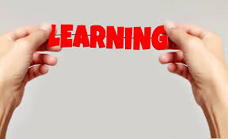

- Understand the potential benefits of using SEM over path analysis
- Estimate internal consistency values in R
- Specify, estimate, and interpret SEM models in R

# SEM: bringing CFA and path analysis together

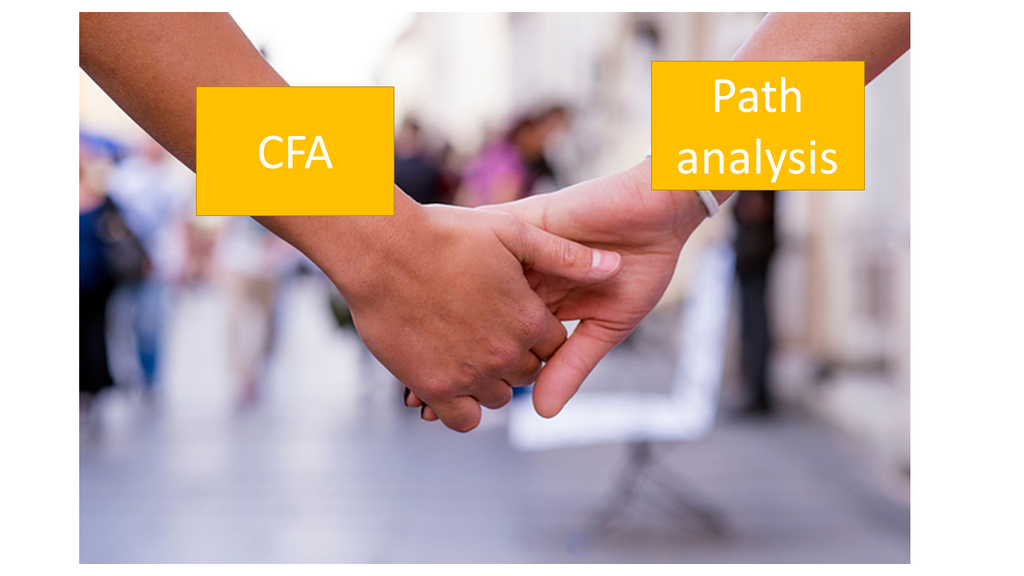

- We previously talked about how we can test latent variable models for constructs using CFA
  - e.g., a two-factor model of aggression
- We separately talked about how we can use path analysis to test sets of regression models
  - e.g., a model to test whether peer rejection mediates the association between aggression and depression
- SEM combines CFA and path analysis

# A structural equation model

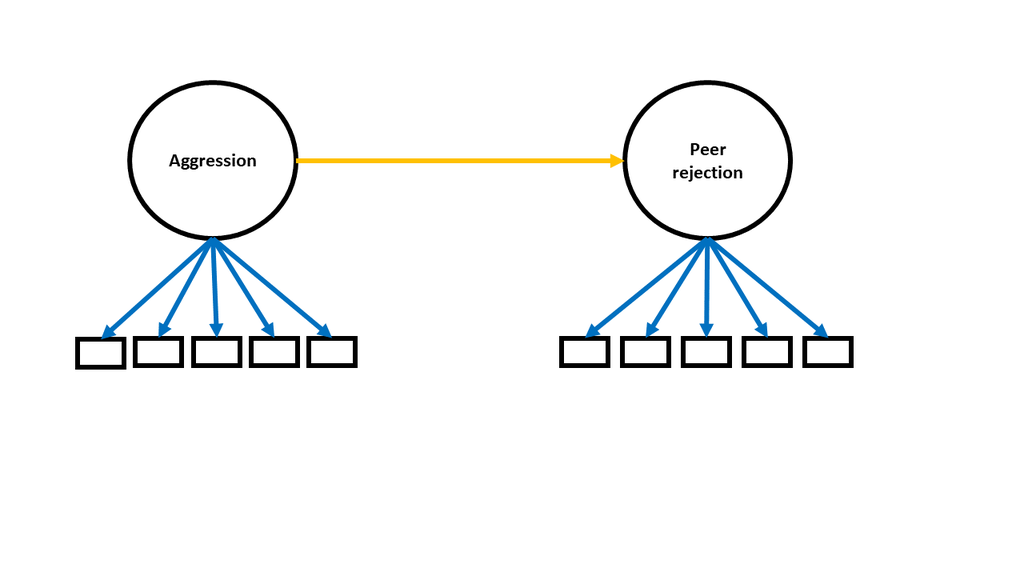

- SEM models regression paths between latent variables (the ‘**structural**’ part of the model)
- The latent variables are from CFA measurement models (the ‘**measurement**’ part of the model)

# Why use a SEM model?

- Our measures of psychological constructs have imperfect **reliability**
- Means scores have a degree of **measurement error** associated with them
- When we want to evaluate the relations between constructs, measurement error gets in they way
- Specifically, we are liable to underestimate the strength of relations between constructs when there is measurement error
- This is called **attenuation due to unreliability**
- Lower reliability measures lead to greater attenuation
- SEM allows disattenuated estimates to be obtained

# BREAK 1

- Time for a pause
- Quiz question
- What is the main difference between path analysis and full SEM ?:
  - 1. full SEM includes latent common factors
  - 2. path analysis allows disattenuated estimates of construct relations
  - 3. path analysis includes a CFA measurement model
  - 4. full SEM assumes perfect reliability of constructs

# WELCOME BACK 1

- Welcome back!
- The answer to the quiz question is…
- What is the main difference between path analysis and full SEM ?:
  - 1. **full SEM includes latent common factors**
  - 2. path analysis allows disattenuated estimates of construct relations
  - 3. path analysis includes a CFA measurement model
  - 4. full SEM assumes perfect reliability of constructs

# A brief detour into reliability

- Reliability theory suggests that:

$$Observed Score= True Score +
Error$$

- We can try to estimate how much of the variance in observed scores is due to error variance based on consistency of scores:
  - across repeated administration of a measure over time (e.g., two weeks apart) (**test-retest reliability**)
  - across parallel forms of a test (**alternate forms reliability**)
    - used to try and avoid practice effects
  - across different raters (**inter-rater reliability**)
    - e.g., teacher versus parent reports of aggression
  - across items within a test (**internal consistency**)

# Internal consistency reliability

- Concerns correlations between items within same scale
- Logic is that if a measure is reliable, items within the measure should be correlated because they all reflect the construct well
- Traditional method was **split-half** reliability
  - Divide test in two and correlate scores across the two halves
  - However, many possible ways to divide a test in two…

# Cronbach’s alpha

$$\large \alpha$$

- **Cronbach’s alpha** is a generalisation of split half-reliability
- Can be roughly interpreted as a measure of average correlation between all possible two-way splits of a measure
- Ranges from 0 to 1
- Values > .70 considered acceptable
- Most popular measure of reliability
- **However**, it assumes that all items are equally strongly correlated with underlying construct
  - i.e., assumes equal factor loadings
- Rarely true and is a big limitation of Cronbach’s alpha

# Omega

$$\large \omega$$

- **Omega** is an alternative measure of internal consistency reliability
- Based on the loadings from a factor analysis
- It is an estimate of the variance in the sum of all items (‘total score’) attributable to the latent factor(s)
- Ranges from 0 to 1
- Values > .70 considered acceptable
- Does not assume that the loadings are equal for all items
  - This makes it a better measure of internal consistency than Cronbach’s alpha
- **Use omega rather than Cronbach’s alpha to assess internal consistency**

# Alpha and omega in R

- We could compute alpha and omega for our aggression data from the PCA, EFA and CFA lectures
- Recall:
  - we had 10 aggression items
  - We determined using an EFA and then a CFA in new data that a model with two correlated factors was best
  - the two factors were labelled ‘verbal aggression’ and ‘physical aggression’

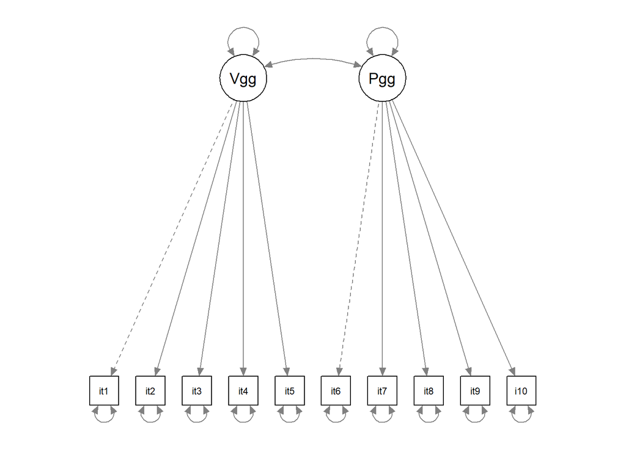

# Alpha and omega for our aggression subscales

- We can use the omega() function from the psych package to compute internal consistency for each set of 5 items
- We let omega() know which items we wish to compute internal consistency for
  - Here the first five items of our aggression measure
- We let omega() know that these items consistute one factor by setting nfactors=1

```r
library(psych)
omega_verbal<-omega(agg.items[ ,c(1:5)], nfactors=1) ##omega for the verbal aggression factor (items 1-5)
```

```
## Omega_h for 1 factor is not meaningful, just omega_t
```

# omega() output

```r
omega_verbal
```

```
## Omega
## Call: omegah(m = m, nfactors = nfactors, fm = fm, key = key, flip = flip,
##     digits = digits, title = title, sl = sl, labels = labels,
##     plot = plot, n.obs = n.obs, rotate = rotate, Phi = Phi, option = option,
##     covar = covar)
## Alpha:                 0.87
## G.6:                   0.84
## Omega Hierarchical:    0.87
## Omega H asymptotic:    1
## Omega Total            0.87
##
## Schmid Leiman Factor loadings greater than  0.2
##          g  F1*   h2   u2 p2
## item1 0.72      0.51 0.49  1
## item2 0.80      0.64 0.36  1
## item3 0.73      0.53 0.47  1
## item4 0.69      0.47 0.53  1
## item5 0.85      0.72 0.28  1
##
## With Sums of squares  of:
##   g F1*
## 2.9 0.0
##
## general/max  Inf   max/min =   NaN
## mean percent general =  1    with sd =  0 and cv of  0
## Explained Common Variance of the general factor =  1
##
## The degrees of freedom are 5  and the fit is  0
## The number of observations was  1000  with Chi Square =  1.17  with prob <  0.95
## The root mean square of the residuals is  0
## The df corrected root mean square of the residuals is  0.01
## RMSEA index =  0  and the 10 % confidence intervals are  0 0.005
## BIC =  -33.37
##
## Compare this with the adequacy of just a general factor and no group factors
## The degrees of freedom for just the general factor are 5  and the fit is  0
## The number of observations was  1000  with Chi Square =  1.17  with prob <  0.95
## The root mean square of the residuals is  0
## The df corrected root mean square of the residuals is  0.01
##
## RMSEA index =  0  and the 10 % confidence intervals are  0 0.005
## BIC =  -33.37
##
## Measures of factor score adequacy
##                                                  g F1*
## Correlation of scores with factors            0.94   0
## Multiple R square of scores with factors      0.88   0
## Minimum correlation of factor score estimates 0.76  -1
##
##  Total, General and Subset omega for each subset
##                                                  g  F1*
## Omega total for total scores and subscales    0.87 0.87
## Omega general for total scores and subscales  0.87 0.87
## Omega group for total scores and subscales    0.00 0.00
```

- ‘Alpha’ gives us our Cronbach’s alpha value
- ‘omega Total’ gives us our omega value

# Alpha and omega

- We can do the same for the physical aggression items

```r
omega_physical<-omega(agg.items[ ,c(6:10)], nfactors=1) ## calculate alpha and omega for the physical aggression factor
```

```
## Omega_h for 1 factor is not meaningful, just omega_t
```

# omega() output for physical aggression

```r
omega_physical
```

```
## Omega
## Call: omegah(m = m, nfactors = nfactors, fm = fm, key = key, flip = flip,
##     digits = digits, title = title, sl = sl, labels = labels,
##     plot = plot, n.obs = n.obs, rotate = rotate, Phi = Phi, option = option,
##     covar = covar)
## Alpha:                 0.89
## G.6:                   0.87
## Omega Hierarchical:    0.89
## Omega H asymptotic:    1
## Omega Total            0.89
##
## Schmid Leiman Factor loadings greater than  0.2
##           g  F1*   h2   u2 p2
## item6  0.66      0.44 0.56  1
## item7  0.90      0.81 0.19  1
## item8  0.92      0.85 0.15  1
## item9  0.70      0.49 0.51  1
## item10 0.74      0.55 0.45  1
##
## With Sums of squares  of:
##   g F1*
## 3.1 0.0
##
## general/max  Inf   max/min =   NaN
## mean percent general =  1    with sd =  0 and cv of  0
## Explained Common Variance of the general factor =  1
##
## The degrees of freedom are 5  and the fit is  0.01
## The number of observations was  1000  with Chi Square =  6.81  with prob <  0.24
## The root mean square of the residuals is  0.01
## The df corrected root mean square of the residuals is  0.01
## RMSEA index =  0.019  and the 10 % confidence intervals are  0 0.051
## BIC =  -27.73
##
## Compare this with the adequacy of just a general factor and no group factors
## The degrees of freedom for just the general factor are 5  and the fit is  0.01
## The number of observations was  1000  with Chi Square =  6.81  with prob <  0.24
## The root mean square of the residuals is  0.01
## The df corrected root mean square of the residuals is  0.01
##
## RMSEA index =  0.019  and the 10 % confidence intervals are  0 0.051
## BIC =  -27.73
##
## Measures of factor score adequacy
##                                                  g F1*
## Correlation of scores with factors            0.96   0
## Multiple R square of scores with factors      0.93   0
## Minimum correlation of factor score estimates 0.86  -1
##
##  Total, General and Subset omega for each subset
##                                                  g  F1*
## Omega total for total scores and subscales    0.89 0.89
## Omega general for total scores and subscales  0.89 0.89
## Omega group for total scores and subscales    0.00 0.00
```

# How to solve the problem of attenuation due to unreliability?

- Traditional method was to apply a formula to correct correlations for unreliability:

$$\frac{r_{xy}}{\sqrt{r_{xx}r_{yy}}}$$

- Where: - $r_{xy}$ is the uncorrected correlation between variables $x$ and $y$ - $r_{xx}$ is an estimate of the reliability of variable $x$ - $r_{yy}$ is an estimate of the reliability of variable $y$
- However, this requires multiple steps (compute reliability, correct correlations)
- Further complicated when it’s a whole correlation matrix that requires correction
- SEM can solve the problem in a single step

# BREAK 2

- Time for a pause
- Quiz question:
- Which of these R functions from the psych package can be used to calculate Cronbach’s alpha?:
  - 1. gamma()
  - 2. beta()
  - 3. delta()
  - 4. omega()

# WELCOME BACK 2

- Welcome back!
- The answer to the quiz question is…
- Quiz question:
- Which of these R functions from the psych package can be used to calculate Cronbach’s alpha?:
  - 1. gamma()
  - 2. beta()
  - 3. delta()
  - 4. **omega()**

# Addressing attenuation due to unreliability with SEM

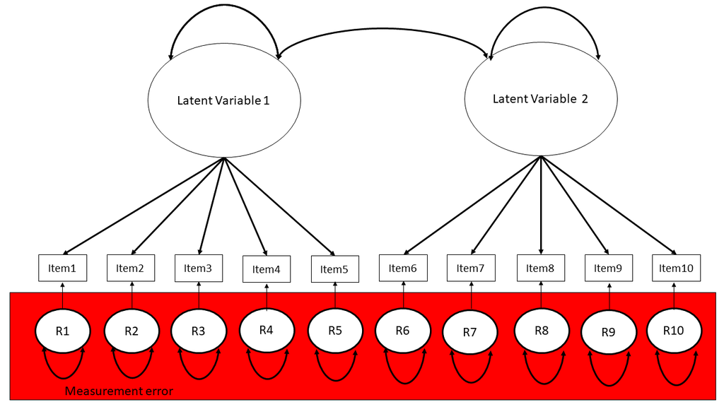

- SEM can solve the problem of attenuation due to unreliability
- It uses latent variable measurement models from CFA
- These models separate out systematic variance (latent common factors) and measurement error variance (residual factors)
- The relations between constructs are tested using the latent common factors i.e., the error-free parts

# Fitting structural equation models

- Fitting SEMs follows the same process as CFA and path analyis:
  - Model specification
  - Model estimation
  - Model evaluation
  - (Model modification)
  - Model interpretation
- However, we usually want to test our measurement models first using CFAs for each construct

# An example SEM model

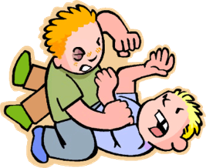

- Imagine we wanted to know whether verbal and physical aggression predicted peer rejection in children, accounting for imperfect reliability
- We have a sample of n=570
- We have a 10-item aggression measure to measure verbal and physical aggression (5 items each)
- We have a 5-item peer rejection measure
- We can fit a SEM to assess whether latent verbal and physical aggression factors predict a latent peer rejection factor

# Our model

- The model we want to test looks like:

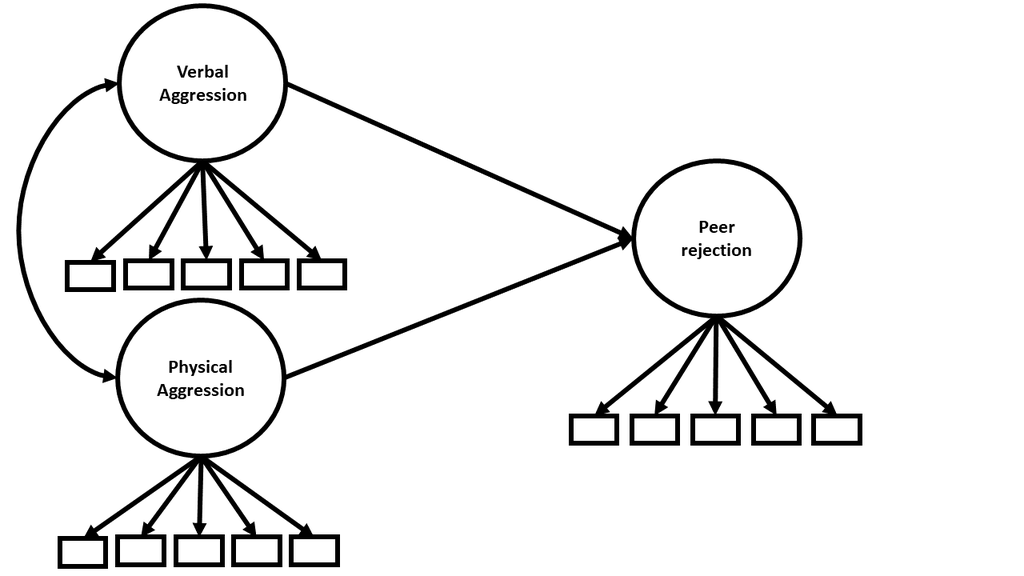

# Step 1: check the measurement models

- First we would conduct a CFA for aggression and a CFA for peer rejection
  - i.e., we first test our proposed measurement models
- We do this as a first step because mis-fit is most often due to measurement rather than structural part of the model

# CFA for aggression

- We fit a two-factor CFA with correlated factors for aggression
- By default, the first loading for each factor will be fixed to 1 for scaling/identification

```r
##CFA for aggression

agg.CFA<-'Vagg=~agg1+agg2+agg3+agg4+agg5

   Pagg=~agg6+agg7+agg8+agg9+agg10

   Vagg~~Pagg'

agg.CFA.est<-cfa(agg.CFA, data=agg.PR.data)
summary(agg.CFA.est, fit.measures=T, standardized=T)
```

```
## lavaan 0.6.15 ended normally after 30 iterations
##
##   Estimator                                         ML
##   Optimization method                           NLMINB
##   Number of model parameters                        21
##
##   Number of observations                           570
##
## Model Test User Model:
##
##   Test statistic                                46.611
##   Degrees of freedom                                34
##   P-value (Chi-square)                           0.073
##
## Model Test Baseline Model:
##
##   Test statistic                              3343.183
##   Degrees of freedom                                45
##   P-value                                        0.000
##
## User Model versus Baseline Model:
##
##   Comparative Fit Index (CFI)                    0.996
##   Tucker-Lewis Index (TLI)                       0.995
##
## Loglikelihood and Information Criteria:
##
##   Loglikelihood user model (H0)              -6599.772
##   Loglikelihood unrestricted model (H1)      -6576.466
##
##   Akaike (AIC)                               13241.543
##   Bayesian (BIC)                             13332.802
##   Sample-size adjusted Bayesian (SABIC)      13266.136
##
## Root Mean Square Error of Approximation:
##
##   RMSEA                                          0.026
##   90 Percent confidence interval - lower         0.000
##   90 Percent confidence interval - upper         0.042
##   P-value H_0: RMSEA <= 0.050                    0.994
```

[output cut: 31 more lines]

```
##
## Variances:
##                    Estimate  Std.Err  z-value  P(>|z|)   Std.lv  Std.all
##    .agg1              0.480    0.033   14.488    0.000    0.480    0.456
##    .agg2              0.340    0.027   12.380    0.000    0.340    0.312
##    .agg3              0.550    0.036   15.164    0.000    0.550    0.538
##    .agg4              0.567    0.037   15.204    0.000    0.567    0.543
##    .agg5              0.300    0.025   11.843    0.000    0.300    0.288
##    .agg6              0.560    0.036   15.707    0.000    0.560    0.540
##    .agg7              0.222    0.021   10.816    0.000    0.222    0.193
##    .agg8              0.206    0.019   10.917    0.000    0.206    0.196
##    .agg9              0.504    0.033   15.123    0.000    0.504    0.442
##    .agg10             0.458    0.030   15.374    0.000    0.458    0.479
##     Vagg              0.572    0.058    9.862    0.000    1.000    1.000
##     Pagg              0.477    0.053    8.943    0.000    1.000    1.000
```

# CFA for peer rejection

- We fit a CFA for peer rejection
- By default, the loading for the first item will be fixed to 1 for scaling/identification

```r
##CFA for aggression

PR.CFA<-'PR=~PR1+PR2+PR3+PR4+PR5'


PR.CFA.est<-cfa(PR.CFA, data=agg.PR.data)
summary(PR.CFA.est, fit.measures=T, standardized=T)
```

```
## lavaan 0.6.15 ended normally after 24 iterations
##
##   Estimator                                         ML
##   Optimization method                           NLMINB
##   Number of model parameters                        10
##
##   Number of observations                           570
##
## Model Test User Model:
##
##   Test statistic                                 7.228
##   Degrees of freedom                                 5
##   P-value (Chi-square)                           0.204
##
## Model Test Baseline Model:
##
##   Test statistic                              1978.376
##   Degrees of freedom                                10
##   P-value                                        0.000
##
## User Model versus Baseline Model:
##
##   Comparative Fit Index (CFI)                    0.999
##   Tucker-Lewis Index (TLI)                       0.998
##
## Loglikelihood and Information Criteria:
##
##   Loglikelihood user model (H0)              -3097.913
##   Loglikelihood unrestricted model (H1)      -3094.298
##
##   Akaike (AIC)                                6215.825
##   Bayesian (BIC)                              6259.281
##   Sample-size adjusted Bayesian (SABIC)       6227.536
##
## Root Mean Square Error of Approximation:
##
##   RMSEA                                          0.028
##   90 Percent confidence interval - lower         0.000
##   90 Percent confidence interval - upper         0.069
##   P-value H_0: RMSEA <= 0.050                    0.771
```

[output cut: 14 more lines]

```
##   PR =~
##     PR1               1.000                               0.769    0.776
##     PR2               1.047    0.051   20.476    0.000    0.805    0.798
##     PR3               1.211    0.050   24.145    0.000    0.931    0.914
##     PR4               1.176    0.051   22.847    0.000    0.904    0.871
##     PR5               1.031    0.052   19.959    0.000    0.792    0.781
##
## Variances:
##                    Estimate  Std.Err  z-value  P(>|z|)   Std.lv  Std.all
##    .PR1               0.391    0.026   14.868    0.000    0.391    0.398
##    .PR2               0.370    0.025   14.536    0.000    0.370    0.364
##    .PR3               0.171    0.017   10.020    0.000    0.171    0.165
##    .PR4               0.259    0.021   12.521    0.000    0.259    0.241
##    .PR5               0.401    0.027   14.790    0.000    0.401    0.390
##     PR                0.591    0.055   10.783    0.000    1.000    1.000
```

# Step 2: specify the SEM model

- Assuming the measurement models show good fit, we proceed to specifying the full SEM
- The SEM specification combines the measurement models with the hypothesised structural relations between the latent variables
- Just as with CFA and path analysis, model must be identified
  - The number of ‘knowns’ are at least as many as the ‘unknowns’

```r
agg.PR.model<-'
# aggression measurement model
   Vagg=~agg1+agg2+agg3+agg4+agg5

   Pagg=~agg6+agg7+agg8+agg9+agg10

   Vagg~~Pagg

# peer rejection measurement model
   PR=~PR1+PR2+PR3+PR4+PR5

#structural part of the model

  PR~Vagg + Pagg        # Peer rejection is regressed on verbal and physical aggression'
```

# Step 3: estimate the SEM model

- As for CFA and path analysis, we can use maximum likelihood estimation to estimate the parameters
- As for path analysis we can do this using the sem() function from lavaan
- We provide the name of the model and the dataset

```r
agg.PR.est<-sem(agg.PR.model, data= agg.PR.data)
```

# Step 4: evaluate the model

- We look at the fit statistics and check they are satisfactory
- We are looking for TLI and CFI>.95; RMSEA and SRMR<.05
- We can inspect the fit statistics using the summary() function, setting fit.measures=T

```r
summary(agg.PR.est, fit.measures=T)
```

```
## lavaan 0.6.15 ended normally after 35 iterations
##
##   Estimator                                         ML
##   Optimization method                           NLMINB
##   Number of model parameters                        33
##
##   Number of observations                           570
##
## Model Test User Model:
##
##   Test statistic                               107.429
##   Degrees of freedom                                87
##   P-value (Chi-square)                           0.068
##
## Model Test Baseline Model:
##
##   Test statistic                              5508.400
##   Degrees of freedom                               105
##   P-value                                        0.000
##
## User Model versus Baseline Model:
##
##   Comparative Fit Index (CFI)                    0.996
##   Tucker-Lewis Index (TLI)                       0.995
##
## Loglikelihood and Information Criteria:
##
##   Loglikelihood user model (H0)              -9631.059
##   Loglikelihood unrestricted model (H1)      -9577.344
##
##   Akaike (AIC)                               19328.118
##   Bayesian (BIC)                             19471.524
##   Sample-size adjusted Bayesian (SABIC)      19366.763
##
## Root Mean Square Error of Approximation:
##
##   RMSEA                                          0.020
##   90 Percent confidence interval - lower         0.000
##   90 Percent confidence interval - upper         0.032
##   P-value H_0: RMSEA <= 0.050                    1.000
```

[output cut: 49 more lines]

```
##    .agg4              0.566    0.037   15.211    0.000
##    .agg5              0.301    0.025   11.929    0.000
##    .agg6              0.562    0.036   15.723    0.000
##    .agg7              0.223    0.020   10.898    0.000
##    .agg8              0.208    0.019   11.035    0.000
##    .agg9              0.500    0.033   15.115    0.000
##    .agg10             0.457    0.030   15.379    0.000
##    .PR1               0.391    0.026   14.913    0.000
##    .PR2               0.368    0.025   14.578    0.000
##    .PR3               0.169    0.017   10.115    0.000
##    .PR4               0.264    0.021   12.745    0.000
##    .PR5               0.400    0.027   14.835    0.000
##     Vagg              0.572    0.058    9.870    0.000
##     Pagg              0.476    0.053    8.927    0.000
##    .PR                0.450    0.043   10.596    0.000
```

# Step 5: interpret the model

- We can see whether the regression paths are significant using the summary() function
- We can also look at the standardised coefficients by setting standardized=T

```r
summary(agg.PR.est, fit.measures=T, standardized=T)
```

```
## lavaan 0.6.15 ended normally after 35 iterations
##
##   Estimator                                         ML
##   Optimization method                           NLMINB
##   Number of model parameters                        33
##
##   Number of observations                           570
##
## Model Test User Model:
##
##   Test statistic                               107.429
##   Degrees of freedom                                87
##   P-value (Chi-square)                           0.068
##
## Model Test Baseline Model:
##
##   Test statistic                              5508.400
##   Degrees of freedom                               105
##   P-value                                        0.000
##
## User Model versus Baseline Model:
##
##   Comparative Fit Index (CFI)                    0.996
##   Tucker-Lewis Index (TLI)                       0.995
##
## Loglikelihood and Information Criteria:
##
##   Loglikelihood user model (H0)              -9631.059
##   Loglikelihood unrestricted model (H1)      -9577.344
##
##   Akaike (AIC)                               19328.118
##   Bayesian (BIC)                             19471.524
##   Sample-size adjusted Bayesian (SABIC)      19366.763
##
## Root Mean Square Error of Approximation:
##
##   RMSEA                                          0.020
##   90 Percent confidence interval - lower         0.000
##   90 Percent confidence interval - upper         0.032
##   P-value H_0: RMSEA <= 0.050                    1.000
```

[output cut: 49 more lines]

```
##    .agg4              0.566    0.037   15.211    0.000    0.566    0.542
##    .agg5              0.301    0.025   11.929    0.000    0.301    0.289
##    .agg6              0.562    0.036   15.723    0.000    0.562    0.542
##    .agg7              0.223    0.020   10.898    0.000    0.223    0.194
##    .agg8              0.208    0.019   11.035    0.000    0.208    0.197
##    .agg9              0.500    0.033   15.115    0.000    0.500    0.439
##    .agg10             0.457    0.030   15.379    0.000    0.457    0.478
##    .PR1               0.391    0.026   14.913    0.000    0.391    0.398
##    .PR2               0.368    0.025   14.578    0.000    0.368    0.362
##    .PR3               0.169    0.017   10.115    0.000    0.169    0.163
##    .PR4               0.264    0.021   12.745    0.000    0.264    0.245
##    .PR5               0.400    0.027   14.835    0.000    0.400    0.389
##     Vagg              0.572    0.058    9.870    0.000    1.000    1.000
##     Pagg              0.476    0.053    8.927    0.000    1.000    1.000
##    .PR                0.450    0.043   10.596    0.000    0.762    0.762
```

# Making model modifications in SEM

- Our initially hypothesised model may not be optimal
  - We didn’t include paths that we should have (check expected parameter changes and modification indices)
  - Some included paths are non-significant and could be trimmed
- These issues may affect the measurement or structural part of the model
  - But more often mis-fit relates to the measurement part
  - Aim to make any modifications in the measurement part in initial CFAs before fitting the full SEM
- Carefully consider before making modifications
  - Can they be theoretically justified?
  - Am I likely to be just capitalising on chance?
- Aim to replicate the modified model in new data

# Check modification indices and expected parameter changes

```r
modindices(agg.PR.est, sort=T)
```

```
##       lhs op   rhs     mi    epc sepc.lv sepc.all sepc.nox
## 68   agg1 ~~  agg3 10.595 -0.082  -0.082   -0.160   -0.160
## 95   agg3 ~~  agg5  8.947  0.069   0.069    0.170    0.170
## 137  agg7 ~~  agg9  7.264 -0.056  -0.056   -0.167   -0.167
## 45   Vagg =~   PR4  6.615 -0.102  -0.077   -0.075   -0.075
## 102  agg3 ~~   PR2  5.852  0.051   0.051    0.113    0.113
## 65     PR =~  agg9  5.242  0.112   0.086    0.081    0.081
## 131  agg6 ~~   PR1  4.855  0.047   0.047    0.101    0.101
## 123  agg5 ~~   PR2  4.643 -0.037  -0.037   -0.112   -0.112
## 119  agg5 ~~  agg8  4.337 -0.031  -0.031   -0.122   -0.122
## 169   PR3 ~~   PR4  4.283  0.038   0.038    0.180    0.180
## 106  agg4 ~~  agg5  4.227 -0.048  -0.048   -0.116   -0.116
## 167   PR2 ~~   PR4  4.102 -0.036  -0.036   -0.117   -0.117
## 104  agg3 ~~   PR4  4.019 -0.038  -0.038   -0.099   -0.099
## 51   Pagg =~  agg5  3.541 -0.142  -0.098   -0.096   -0.096
```

[output cut: 121 more lines]

# Reporting SEMs

- Main principles: transparency and reproducibility
- Method
  - Describe the measurement model specification and criteria used to evaluate it (model fit etc.)
  - Describe the SEM model specification and criteria used to evaluate it
  - Explain how the model specification operationalises your hypothesis/hypotheses
- Results
  - Fit for the initial CFAs
  - Fit for the SEM (SRMR, RMSEA, TLI, CFI)
  - Any modifications made and why
  - All parameter estimates from the SEM
    - diagram can again be helpful for visualising model
    - may need to show the structural and measurement parts of the model separately for visual clarity

# Cautions regarding the use of SEM

- We assume the paths represent causal relations but this is an assumption
  - Especially when using cross-sectional data
- Well-fitting models do not guarantee that we have found the ‘correct’ model
- Our parameter estimates are correct only if the model is correctly specified

# Path vs SEM models

- SEM models can adjust for attenuation due to unreliability
- This means that structural associations tend to be larger (and arguably more accurate)
- It makes SEM preferable to path analysis

# SEM summary

- Full SEM models combine CFA and path analysis
- The steps in a SEM are:
  - Test the measurement models (specification, estimation, evaluation & modification)
  - Specify the full SEM
  - Estimate the full SEM
  - Evaluate the full SEM
- Paths are usually assumed to represent causal effects but this is only an assumption